# Peer-graded assignment: by Ghazal Montaseri

## Problem statement

The goal of this project is to predict the manner in which people did the exercise. The output variable is “classe”. We want to fit a predictor to the train data and then use the prediction model to predict 20 different test cases. To build a predictor model, we use data from accelerometers on the belt, forearm, arm, and dumbell of 6 participants. They were asked to perform barbell lifts correctly and incorrectly in 5 different ways (5 classes).

## Loading libraries

```r
rm(list = ls())
library(ggplot2)
library(caret)
library(dplyr)
library(rattle)
library(rpart)
library(rpart.plot)
library(corrplot)
library(randomForest)
library(RColorBrewer)
```

# Importing train data and exploratory analysis

```r
setwd("~/")
set.seed(123)
training.raw = read.csv(file = '~/pml-training.csv', na.strings=c("<NA>","NA"))
test.raw     = read.csv(file = '~/pml-testing.csv', na.strings=c("<NA>","NA"))

dim(training.raw)
```

```
## [1] 19622   160
```

```r
dim(test.raw)
```

```
## [1]  20 160
```

# Remove the columns which are not features

In the next step, we clean the training and test dataset in a way that columns without any information. By that, 5 columns were excluded from datasets.

```r
training = training.raw[,-c(1:5)]
testing  =  test.raw[,-c(1:5)]

dim(training)
```

```
## [1] 19622   155
```

```r
dim(testing)
```

```
## [1]  20 155
```

# Remove the columns with near zero variance

Then, we clean the data such that features with near zero variance were removed. By that, 60 features were removed and now the dataset contains 95 features. Note, all data processing methods should apply to both test and training data.

```r
nzv = nearZeroVar(training, saveMetrics= TRUE)

training = training[, !nzv$nzv]
testing  = testing[, !nzv$nzv]

dim(training)
```

```
## [1] 19622    95
```

```r
dim(testing)
```

```
## [1] 20 95
```

# Remove the columns which which contain `NA`.

```r
training = training[,colMeans(is.na(training)) < 0.5]
testing  = testing[,colMeans(is.na(testing)) < 0.5]

dim(training)
```

```
## [1] 19622    54
```

```r
dim(testing)
```

```
## [1] 20 54
```

# Plot Correlation Matrix of features in the traing datset

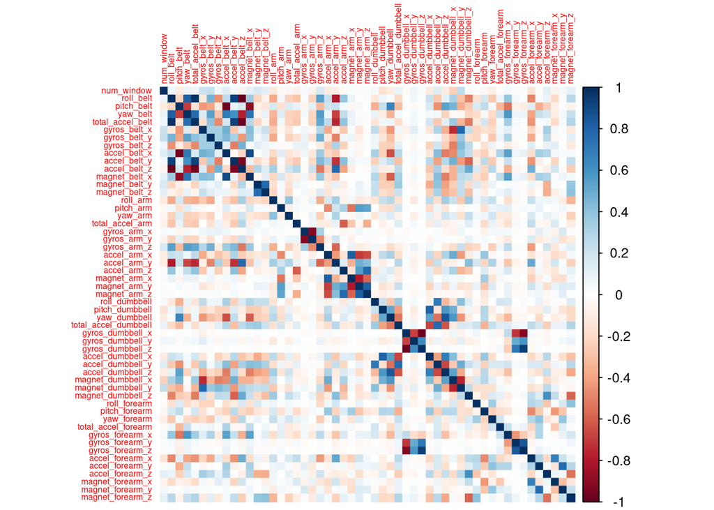

```r
corrplot(cor(training[, -length(names(training))]), method = "color", tl.cex = 0.5)
```

# Generate validation dataset from training dataset

To test the performance of our model prediction before going to the main test dataset, we can evaluate the model based on the validation data. To do so, we do partitioning and get 70% training and 30 % validation dataset.

```r
set.seed(123)
inTrain =  createDataPartition(training$classe, p = 0.70, list = FALSE)
validation =  training[-inTrain, ]
training   = training[inTrain, ]
```

# Creat a ML model and check its accuracy on the training dataset

We start with the decision tree model and calculate the confusion matrix. Accuracy of the model on the training data is 0.8295.

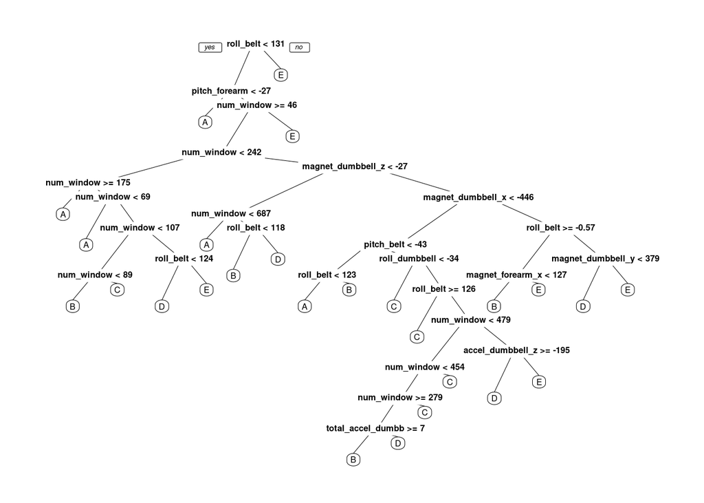

```r
modFit = rpart(classe ~ ., data = training, method = "class")
prp(modFit)
```

```r
pred = predict(modFit, newdata=training, , type = "class")
table(pred, training$classe)
```

```
##
## pred    A    B    C    D    E
##    A 3470  245    5   37   13
##    B  194 2012  151  195  128
##    C    1  148 1979   89   10
##    D  208  158  243 1731  171
##    E   33   95   18  200 2203
```

```r
confusionMatrix(as.factor(training$classe), as.factor(pred))
```

```
## Confusion Matrix and Statistics
##
##           Reference
## Prediction    A    B    C    D    E
##          A 3470  194    1  208   33
##          B  245 2012  148  158   95
##          C    5  151 1979  243   18
##          D   37  195   89 1731  200
##          E   13  128   10  171 2203
##
## Overall Statistics
##
##                Accuracy : 0.8295
##                  95% CI : (0.8231, 0.8358)
##     No Information Rate : 0.2744
##     P-Value [Acc > NIR] : < 2.2e-16
##
##                   Kappa : 0.7847
##
##  Mcnemar's Test P-Value : < 2.2e-16
##
## Statistics by Class:
##
##                      Class: A Class: B Class: C Class: D Class: E
## Sensitivity            0.9204   0.7507   0.8886   0.6894   0.8643
## Specificity            0.9563   0.9416   0.9638   0.9536   0.9712
## Pos Pred Value         0.8884   0.7570   0.8260   0.7687   0.8725
## Neg Pred Value         0.9695   0.9397   0.9781   0.9321   0.9691
## Prevalence             0.2744   0.1951   0.1621   0.1828   0.1856
## Detection Rate         0.2526   0.1465   0.1441   0.1260   0.1604
## Detection Prevalence   0.2843   0.1935   0.1744   0.1639   0.1838
## Balanced Accuracy      0.9383   0.8462   0.9262   0.8215   0.9177
```

# Check decision tree model’s accuracy on the validation dataset

Compared to the training dataset, Accuracy is abit reduced (= 0.8274 ) in the validation dataset.

```r
predVal = predict(modFit, newdata=validation, , type = "class")
table(predVal, validation$classe)
```

```
##
## predVal    A    B    C    D    E
##       A 1459   86    0   13    2
##       B  104  855   61   75   51
##       C    0   57  856   37    3
##       D   92   81   99  759   86
##       E   19   60   10   80  940
```

```r
confusionMatrix(as.factor(validation$classe), as.factor(predVal))
```

```
## Confusion Matrix and Statistics
##
##           Reference
## Prediction    A    B    C    D    E
##          A 1459  104    0   92   19
##          B   86  855   57   81   60
##          C    0   61  856   99   10
##          D   13   75   37  759   80
##          E    2   51    3   86  940
##
## Overall Statistics
##
##                Accuracy : 0.8274
##                  95% CI : (0.8175, 0.8369)
##     No Information Rate : 0.2651
##     P-Value [Acc > NIR] : < 2.2e-16
##
##                   Kappa : 0.7823
##
##  Mcnemar's Test P-Value : NA
##
## Statistics by Class:
##
##                      Class: A Class: B Class: C Class: D Class: E
## Sensitivity            0.9353   0.7461   0.8982   0.6795   0.8476
## Specificity            0.9503   0.9401   0.9655   0.9570   0.9703
## Pos Pred Value         0.8716   0.7507   0.8343   0.7873   0.8688
## Neg Pred Value         0.9760   0.9387   0.9800   0.9273   0.9648
## Prevalence             0.2651   0.1947   0.1619   0.1898   0.1884
## Detection Rate         0.2479   0.1453   0.1455   0.1290   0.1597
## Detection Prevalence   0.2845   0.1935   0.1743   0.1638   0.1839
## Balanced Accuracy      0.9428   0.8431   0.9319   0.8183   0.9089
```

# Check if we can improve accuracy of the ML model

As the second ML technique, we select random forest and check its performance on the validation dataset to compare it with the decision tree model we have already generated. Using the random forest algorithm improves the accuracy from 0.83 to 0.99.Note, if we do not select number of trees, the execution takes long time, so, I set ntree=100 and by that still the accuracy is good.

```r
modFit2 = train(classe ~ ., data = training, method = "rf", ntree=100)

predVal2 = predict(modFit2, validation)

confusionMatrix(as.factor(validation$classe), as.factor(predVal2))
```

```
## Confusion Matrix and Statistics
##
##           Reference
## Prediction    A    B    C    D    E
##          A 1674    0    0    0    0
##          B    2 1135    2    0    0
##          C    0    2 1024    0    0
##          D    0    0    1  963    0
##          E    0    0    0    4 1078
##
## Overall Statistics
##
##                Accuracy : 0.9981
##                  95% CI : (0.9967, 0.9991)
##     No Information Rate : 0.2848
##     P-Value [Acc > NIR] : < 2.2e-16
##
##                   Kappa : 0.9976
##
##  Mcnemar's Test P-Value : NA
##
## Statistics by Class:
##
##                      Class: A Class: B Class: C Class: D Class: E
## Sensitivity            0.9988   0.9982   0.9971   0.9959   1.0000
## Specificity            1.0000   0.9992   0.9996   0.9998   0.9992
## Pos Pred Value         1.0000   0.9965   0.9981   0.9990   0.9963
## Neg Pred Value         0.9995   0.9996   0.9994   0.9992   1.0000
## Prevalence             0.2848   0.1932   0.1745   0.1643   0.1832
## Detection Rate         0.2845   0.1929   0.1740   0.1636   0.1832
## Detection Prevalence   0.2845   0.1935   0.1743   0.1638   0.1839
## Balanced Accuracy      0.9994   0.9987   0.9983   0.9978   0.9996
```

# Predic the manner of subjects in the test dataset

For the final model prediction on the test dataset, we select the random forest model. Predictions are:

```r
predict(modFit2, newdata=testing[, -length(names(testing))])
```

```
##  [1] B A B A A E D B A A B C B A E E A B B B
## Levels: A B C D E
```